# Section 4: Instrumental Variables

Shikhar Singh

3 October 2019

# Review

## Estimands

In the past few weeks we have covered several different estimands: most commonly, the average treatment effect (or `ATE`), and most recently, the complier average causal effect (or `CACE`). By way of review, I will give you a toy dataset, and ask you to estimate the following quantities:

1. Average Treatment Effect (ATE)

$$\begin{equation}
E[Y_i(1) - Y_i(0)]
\end{equation}$$

2. Average Treatment Effect on the Treated (ATT)

$$\begin{equation}
E[Y_i(1) - Y_i(0) | D_i = 1]
\end{equation}$$

3. Average Treatment Effect on Control Units (ATC)

$$\begin{equation}
E[Y_i(1) - Y_i(0) | D_i = 0]
\end{equation}$$

4. Intent to Treat Effect ($ITT_Y$)

$$\begin{equation}
E[Y_i | Z_i = 1] - E[Y_i | Z_i = 0]
\end{equation}$$

5. Complier Average Causal Effect (CACE)

$$\begin{equation}
E[Y_i(1) - Y_i(0) | D_i(1) > D_i(0)]
\end{equation}$$

```r
library(tidyverse)

estimands_dataset <- data_frame(
  ID = c(1:5),
  Y1 = c(5,8,4,6,4),
  Y0 = c(4,5,6,5,3),
  D1 = c(1,1,0,1,1),
  D0 = c(0,0,0,1,0),
  Z = c(1,0,1,0,0),
  D = D1*Z + D0*(1-Z),
  Y_Z1 = Y1*D1 + Y0*(1-D1),
  Y_Z0 = Y1*D0 + Y0*(1-D0),
  Y = Y_Z1*Z + Y_Z0*(1-Z)
)

estimands_dataset %>% select(-c(D,Y_Z1, Y_Z0,Y)) %>%
  knitr::kable(.,
               caption = "Exercise 1: Toy Dataset",
               col.names = c("ID","Y(D=1)","Y(D=0)","D(Z=1)","D(Z=0)","Z"),
               format = "pandoc")
```

Exercise 1: Toy Dataset

| ID | Y(D=1) | Y(D=0) | D(Z=1) | D(Z=0) | Z |
| --- | --- | --- | --- | --- | --- |
| 1 | 5 | 4 | 1 | 0 | 1 |
| 2 | 8 | 5 | 1 | 0 | 0 |
| 3 | 4 | 6 | 0 | 0 | 1 |
| 4 | 6 | 5 | 1 | 1 | 0 |
| 5 | 4 | 3 | 1 | 0 | 0 |

**Answer**

First, lets use the switching equation to create three new columns: $D_i = D_i(1) \times Z_i + D_i(0) \times (1-Z_i)$; $Y_i(D_i(Z_i=1)) = Y_i(1) \times D_i(1) + Y_i(0) \times (1-D_i(1))$; and $Y_i(D_i(Z_i=0)) = Y_i(1) \times D_i(0) + Y_i(0) \times (1-D_i(0))$ This gives the following science table:

```r
estimands_dataset %>%
  knitr::kable(.,
               caption = "Exercise 1: Filling-in columns in the toy dataset",
               col.names = c("ID","Y(D=1)","Y(D=0)","D(Z=1)","D(Z=0)","Z", "D","Y(D(Z=1))","Y(D(Z=0))","Y"),
               format = "pandoc")
```

Exercise 1: Filling-in columns in the toy dataset

| ID | Y(D=1) | Y(D=0) | D(Z=1) | D(Z=0) | Z | D | Y(D(Z=1)) | Y(D(Z=0)) | Y |
| --- | --- | --- | --- | --- | --- | --- | --- | --- | --- |
| 1 | 5 | 4 | 1 | 0 | 1 | 1 | 5 | 4 | 5 |
| 2 | 8 | 5 | 1 | 0 | 0 | 0 | 8 | 5 | 5 |
| 3 | 4 | 6 | 0 | 0 | 1 | 0 | 6 | 6 | 6 |
| 4 | 6 | 5 | 1 | 1 | 0 | 1 | 6 | 6 | 6 |
| 5 | 4 | 3 | 1 | 0 | 0 | 0 | 4 | 3 | 3 |

Next, lets calculate each of the quantities:

1. Average Treatment Effect (ATE) is the average difference in treated and untreated potential outcomes.

$$\begin{equation}
E[Y_i(1) - Y_i(0)] = \frac{5+8+4+6+4}{5} - \frac{4+5+6+5+3}{5} = \frac{27}{5} - \frac{23}{5} = \frac{4}{5} = 0.8
\end{equation}$$

R: `with(data, mean(Y1-Y0))`

2. Average Treatment Effect on the Treated (ATT) is the average difference in treated and untreated potential outcomes of treated subjects (i.e. subjects 1 and 4).

$$\begin{equation}
E[Y_i(1) - Y_i(0) | D_i = 1] = \frac{6+5}{2} - \frac{5+4}{2} = \frac{11-9}{2} = 1
\end{equation}$$

R:`with(data, mean(Y1[D==1]) - mean(Y0[D==1]))`

3. Average Treatment Effect on Control Units (ATC) is the mean difference in the treated and untreated potential outcomes of control subjects (i.e. subjects 2, 3, and 5).

$$\begin{equation}
E[Y_i(1) - Y_i(0) | D_i = 0] = \frac{8+4+4}{3} - \frac{5+6+3}{3} = \frac{16}{3} - \frac{14}{3} = \frac{2}{3} \approx 0.6667
\end{equation}$$

R:`with(data, mean(Y1[D==0]) - mean(Y0[D==0]))`

**Claim:** ATE is a weighted average of ATT and ATC.

$$\begin{equation}
ATE = ATT\times P(D_i=1) + ATC\times P(D_i=0) = (\frac{2}{5}\times 1) + (\frac{3}{5}\times \frac{2}{3}) = \frac{2}{5} + \frac{2}{5} = \frac{4}{5}
\end{equation}$$

4. Intent to Treat Effect ($ITT_Y$) is the mean difference in potential outcomes in the assigned-to-treatment, and assigned-to-control groups.

$$\begin{equation}
E[Y_i | Z_i = 1] - E[Y_i | Z_i = 0] = E[Y_i(D_i(Z_i=1))] - E[Y_i(D_i(Z_i=0))] = \frac{5+8+6+6+4}{5} - \frac{4+5+6+6+3}{5} = \frac{29-24}{5} = 1
\end{equation}$$

R:`with(data, mean(Y_Z1) - mean(Y_Z0))`

**Note:** This is the true value of the $ITT$. Using observable data, we can also get an estimate, $\widehat{ITT}$. That is called the “reduced form” or the difference-in-means: $\overline{Y_{Z=1}} - \overline{Y_{Z=0}}$

$$\begin{equation}
\overline{Y_{Z=1}} - \overline{Y_{Z=0}} = \frac{5+6}{2} - \frac{5+6+3}{3} = \frac{11}{2} - \frac{14}{3} \approx 0.833
\end{equation}$$

R:`with(data, mean(Y[Z==1]) - mean(Y[Z==0]))`

**Furthermore:** We can calculate $ITT_D = E[D_i | Z_i = 1] - E[D_i | Z_i = 0] = E[D_i(Z_i=1)] - E[D_i(Z_i=0)]$. Which is: $(\frac{1+1+0+1+1}{5}) - (\frac{0+0+0+1+0}{5}) = \frac{4}{5} - \frac{1}{5} = \frac{3}{5} = 0.6$. In `R` this is: `with(data, mean(D1) - mean(D0))`. This is different from $\widehat{ITT_D}$, or the first-stage estimate: $\overline{D_{Z=1}} - \overline{D_{Z=0}} = \frac{1+0}{2} - \frac{0+1+0}{3} = 0.16667$. In `R`: `with(data, mean(D[Z==1]) - mean(D[Z==0]))`

5. Complier Average Causal Effect (CACE) is the average difference in treated and untreated potential outcomes of compliers (i.e. subjects that satisfy $D_i(Z_i = 1) > D_i(Z_i = 0)$). In this case, subjects 1, 2 and 5.

$$\begin{equation}
E[Y_i(1) - Y_i(0) | D_i(1) > D_i(0)] = \frac{8+5+4}{3} - \frac{4+5+3}{3} = \frac{17}{3} - \frac{12}{3} \approx 1.6667
\end{equation}$$

R:`with(data, mean(Y1[D1 > D0]) - mean(Y0[D1 > D0]))`

## Fitted and Residualized $D_i$

Consider an outcome $Y$, an explanatory variable $D$, and some confounder $X$. In the past few weeks, we have used a regression of $D$ on $X$ in at least four different ways. As recap, lets go through the various ways in which we used fitted and residualized values of $D$.

Say, the regression specification is:
$$\begin{equation}
D_i = \alpha_0 + \alpha_1 \cdot X_i + \epsilon_i
\end{equation}$$

And the fitted or predicted values are $\widehat{D_i} = \widehat{\alpha_0} + \widehat{\alpha_1} \cdot X_i$; and the residuals are $\tilde{D_i} = D_i - (\widehat{\alpha_0} + \widehat{\alpha_1} \cdot X_i)$.

### Use 1: $\tilde{D_i}$ in the partial regression framework

We showed that in the ordinary least squares regression $Y_i = \beta_0 + \beta_1 \cdot D_i + \beta_2 \cdot X_i + \xi_i$,

> $$\begin{equation} \beta_1 = \frac{cov(\tilde{Y},\tilde{D})}{var(\tilde{D})} \end{equation}$$

$\beta_1$ can be exactly recovered by regressing $D_i$ on $X_i$, collecting the residuals $\tilde{D_i}$, similarly regressing $Y_i$ on $X_i$, collecting the residuals $\tilde{Y_i}$, and running a bivariate regression $\tilde{Y_i} \sim \tilde{D_i}$.

### Use 2: $\tilde{D_i}$ in regression weights

We know that regression weights observations by the conditional variance of treatment, $Var(D_i | X_i)$. Aronow and Samii (2016) tell us:

> We may estimate each of the multiple regression weights with the estimator $\widehat{w_i} = \tilde{D_i^2}$ where $\tilde{D_i}$ is the residual from a regression of $D_i$ on $X_i$. (AS 2016:255)

To understand this, consider the expression $Var(D_i | X_i)$, and re-write it as:

$$\begin{equation}
Var(D_i | X_i) = Var(\widehat{D_i} + \tilde{D_i} | X_i)
\end{equation}$$

We know from the first-order condition while deriving OLS coefficients that $X_i \perp \epsilon_i$, i.e. $E[X_i\epsilon_i] = 0$. Since $\widehat{D_i} = \alpha_0 + \alpha_1 \cdot X_i$ (where $\alpha_0$ and $\alpha_1$ are constants, $\widehat{D_i} \rightarrow f(X_i)$, and $\tilde{D_i} = \epsilon_i$. So $\widehat{D_i} \perp \tilde{D_i}$. This means we can split up the variance as follows:

$$\begin{equation}
Var(\{\alpha_0 + \alpha_1 \cdot X_i\} | X_i) + Var(\tilde{D_i} | X_i)
\end{equation}$$

The first quantity simplifies to $\alpha_1^2 Var(X_i | X_i) = 0$. This leaves:

$$\begin{equation}
Var(\tilde{D_i} | X_i) = E[\tilde{D_i}^2 | X_i] - E[\tilde{D_i} | X_i]^2
\end{equation}$$

But we know that $E[\tilde{D_i} | X_i] = E[\epsilon_i | X_i] = 0$. So we are left with $E[\tilde{D_i}^2]$. This motivates the use of squared-residuals, $\tilde{D_i^2}$, to estimate regression weights.

### Use 3: $\widehat{D_i}$ in propensity score theorem, inverse-probability weighting

The propensity score theorem implies that “the only covariate [we] need to control for is the probability of treatment itself” (Angrist and Pischke, p81).

We know that the propensity score, $p(X_i) = \widehat{D_i} = \widehat{\alpha_0} + \widehat{\alpha_1} \cdot X_i$. In section 2, I showed that we can recover the average treatment effect by weighting outcomes of treated units by $\frac{1}{p(X_i)}$ and outcomes of control units by $\frac{1}{1 - p(X_i)}$. Alternatively, we include $\widehat{D_i}$ as a covariate in the regression $Y_i \sim D_i + \widehat{D_i}$.

### Use 3: $\widehat{D_i}$ in propensity score matching

Finally, last week’s problem set used the propensity score to find matches and estimate the ATT. Ichino and Nathan (2013) have $n = 169$ observations, 86 of which are treated (i.e. primaries are held). One way to find matches for these 86 observations is to identify an untreated observation with the *most similar* propensity score. Here are the steps:

1. Regress $D_i$ on all the covariates $X_{1,i}, X_{2,i} \cdots X_{k,i}$. Capture the predicted values $\widehat{D_i}$.
2. For every treated unit $j$, with propensity score $\widehat{D_j}$, find the nearest untreated subject $k$ in propensity score space, (i.e. $min(\widehat{D_j} - \widehat{D_k})^2$). This produces $j$ pairs, and $2j$ units for the analysis.
3. Estimate the “treatment effect” within each pair, aggregate these estimates, weighting by the probability of treatment (specifically: $\frac{P(D_i = 1 | X_i = x) \cdot P(X_i =x)}{\sum_x P(D_i = 1 | X_i = x) \cdot P(X_i =x)}$).

```r
library(Matching)
library(tidyverse)
library(estimatr)

# Upload the dataset
ndc <- read.csv("primariesdata_NDC.csv")

# Logistic regression of D on all Xs:
prop_model <-
  glm(
  prim_elec ~ pres_t_1 + ethfrac + year2008 + holds1 + incumbent,
  family = "binomial",
  data = ndc
  )

# Extracted the predicted values or "propensity scores"
ndc$propensityscore  <- prop_model$fitted

# Use the Match package, specify X = propensityscore,
# M = 1 (i.e. find only 1 match for each treated unit)

prop_score_estimate <-
  with(ndc, Match(Y = winner_t, Tr = prim_elec, X = propensityscore, M = 1))

summary(prop_score_estimate)
```

```
##
## Estimate...  0.075581
## AI SE......  0.089403
## T-stat.....  0.8454
## p.val......  0.39789
##
## Original number of observations..............  169
## Original number of treated obs...............  86
## Matched number of observations...............  86
## Matched number of observations  (unweighted).  90
```

I want to draw your attention to two facts about matching: (1) we drop untreated observations that are not matched with any treated observation; and (2) we can recycle untreated observations if they are the best match for multiple treated observations.

Here are the treated observations referenced by their row number. Note that `unique(\(\cdot\)) = 86`. `Match` does recycle some treated observations if they have more than 1 equally good matches, then down-weights these observations to maintain $n_{D=1} = 86$

```r
prop_score_estimate$index.treated # 86 unique values
```

```
##  [1]   1   2   3  11  14  15  16  17  19  20  23  24  25  27  29  32  35
## [18]  39  41  42  45  56  57  63  64  65  66  67  69  70  71  72  74  75
## [35]  78  79  80  81  86  86  87  88  90  93  95  97  98  99  99 100 103
## [52] 104 106 107 108 110 112 113 117 118 119 127 128 129 131 133 134 136
## [69] 137 138 142 143 144 147 148 149 151 151 152 153 154 155 156 158 158
## [86] 160 164 167 168 169
```

And here are the “matched” untreated observations, also referenced by their row number. Observe that `unique(\(\cdot\)) = 51`. In other words, some untreated observations are picked as matches multiple times (e.g.: 123 is matched with 2 and 169).

```r
prop_score_estimate$index.control # 51 unique values
```

```
##  [1]  58 123  22 140 139  52   6  55  34 132  33  50  96   6 146 161  68
## [18]  82  36  77 141 116 165 123  82 139  13 139 150  38  76  18 146  31
## [35]  13 139  33  13 125 145  37  34  83 146  44  89  18   9  53  84  62
## [52] 105 157  13  48  55 162  31  92 123  47  37  18  73  92  28 150 121
## [69]  83 139  83  94 146 124 139  83 125 145  83  38  84 135 146 125 145
## [86]  83  46 146  50 123
```

# Instrumental Variables

## Deriving $\beta_{2SLS}$

Consider a treatment $D$ (education), and its impact on an outcome $Y$ (wages). This association is confounded by an unobservable variable, $A$ (ability). Since the effect of education on wages is unidentified, we search for an instrument. We find that an educational body provided college college scholarships ($Z$) to randomly selected high school students. It, however, awarded scholarships with different probabilities to male and female students. Here is a long-form regression and a DAG that captures this information:

$$\begin{equation}
Y_i = \beta_0 + \beta_1 D_i + \beta_2 X_i + \beta_3 A_i + \xi_{0,i}
\end{equation}$$

Where $D_i$ is a dummy variable that equals 1 if the subject finished college, and $\beta_3 A_i + \xi_{1,i}$ is the composite error term because $A_i$ is unobserved.

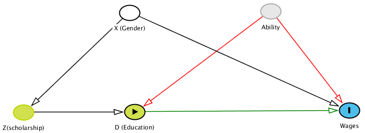

Figure 1: Instrumental Variable Setup

> We will show:
> $$\begin{equation}
> \beta_{2SLS} = \frac{cov(\tilde{Y_i},\tilde{Z_i})}{cov(\tilde{D_i},\tilde{Z_i})} = \frac{\frac{cov(\tilde{Y_i},\tilde{Z_i})}{var(\tilde{Z_i})}}{\frac{cov(\tilde{D_i},\tilde{Z_i})}{var(\tilde{Z_i})}} = \frac{\beta_{Y \cdot Z + X}}{\beta_{D \cdot Z + X}} \end{equation}$$

> $\beta_{2SLS}$ is a ratio of the regression coefficient from the reduced form and first stage.

Consider the “first-stage” regression:

$$\begin{equation}
D_i = \alpha_0 + \alpha_1 X_i + \alpha_2 Z_i + \xi_{1,i}
\end{equation}$$

Plug-in $D_i$ from this equation into the long-form regression:

$$\begin{equation}
Y_i = \beta_0 + \beta_1(\alpha_0 + \alpha_1 X_i + \alpha_2 Z_i + \xi_{1,i}) + \beta_2 X_i + \beta_3 A_i + \xi_{0,i}
\end{equation}$$

And re-arrange the terms so we get:

$$\begin{equation}
Y_i = (\beta_0 + \beta_1 \alpha_0) + X_i(\beta_1 \alpha_1 + \beta_2) + Z_i(\beta_1 \alpha_2) + \{ \beta_1 \xi_{1,i} + \beta_3 A_i + \xi_{0,i}\}
\end{equation}$$

We now have a regression of the type: $Y_i = \pi_0 + \pi_1 X_i + \pi_2 Z_i + \xi_{2,i}$ (or the “reduced form”). Focusing on the coefficients

$$\begin{equation}
\pi_1 = (\beta_1 \alpha_1) + \beta_2
\end{equation}$$

$\beta_1 \alpha_1$ is the “indirect” effect of $X_i$ on $Y_i$, and $\beta_2$ is the “direct” effect of $X_i$ on $Y_i$.

We are interested in isolating $\beta_1$ or the effect of schooling on wages:

$$\begin{equation}
\pi_2 = (\beta_1 \alpha_2) \Rightarrow \beta_1 = \frac{\pi_2}{\alpha_2}
\end{equation}$$

Note that $\pi_2$ captures the variation in $Y_i$ caused by $Z_i$ solely through $D_i$, and $\alpha_2$ captures the variation in $D_i$ caused by $Z_i$. Since $X_i$ is a covariate in both steps, the partial regression framework tells us:

$$\begin{equation}
\pi_2 = \frac{cov(\tilde{Y_i},\tilde{Z_i})}{var(\tilde{Z_i})}
\end{equation}$$
$$\begin{equation}
\alpha_2 = \frac{cov(\tilde{D_i},\tilde{Z_i})}{var(\tilde{Z_i})}
\end{equation}$$

Where $\tilde{D_i}$ is residualized D by partialling-out the variation caused by $X_i$, $\tilde{Y_i}$ is the residual from $Y_i \sim X_i$, and $\tilde{Z_i}$ from $Z_i \sim X_i$.

Finally, if we re-arrange the terms in another way we can see what the second-stage looks like:

$$\begin{equation}
Y_i = (\beta_0 + \beta_1 \alpha_0) + \beta_2 X_i + \beta_1(\alpha_1 X_i + \alpha_2 Z_i) + \{ \beta_1 \xi_{1,i} + \beta_3 A_i + \xi_{0,i}\}
\end{equation}$$

And $\alpha_1 X_i + \alpha_2 Z_i$ are just the fitted values from the first-stage ($D_i \sim Z_i + X_i$).

This is why we do the estimation in two stages:

1. Regress $D_i \sim Z_i + X_i$, and get the fitted values $\widehat{D_i}$
2. Estimate the “second stage” using the fitted values from the first stage: $Y_i \sim \widehat{D_i} + X_i$

## 2SLS in `R`

Let’s confirm the two-stage least squares procedure by doing it manually, then checking if we get the same result by specifying an instrumental variables regression in `iv_robust`. Here is what I do in the attached code:

**Step 1:** Create data in line with the DAG and system of equations specified above.

**Step 2:** Run the “first stage” ($D_i \sim Z_i + X_i$) regression, collect fitted values $\widehat{D_i}$, and plug these into the second stage regression $Y_i \sim \widehat{D_i} + X_i$.

**Step 3:** Specify the IV setup `iv_robust(Y ~ D + X | Z + X, dat)`. Note a few things: (a) we write this in the `outcome ~ endogenous regressor + covariate | instrument + covariate` format; (b) covariates are included in *both* stages (not doing so will produce biased estimates).

**Step 4:** Printing a `htmlreg` table with all three models.

```r
# STEP 1: Create data matching the above specification
library(DeclareDesign)

iv_design <-
  declare_population(N = 2000,
                     noise = rnorm(N, mean = 10, sd = 4),
                     A = rnorm(N),
                     X = rbinom(N, size = 1, prob = 0.48)) +
  declare_potential_outcomes(D ~ as.numeric(pnorm(Z + A) > 0.5),
                             assignment_variables = "Z") +
  declare_potential_outcomes(Y ~  noise + 10*A + 1.25*X + 10*D,
                             assignment_variables = "D") +
  declare_estimand(ATE = mean(Y_D_1 - Y_D_0)) +
  declare_assignment(blocks = X, block_prob = c(0.6, 0.4),
                     assignment_variable = "Z") +
  declare_estimator(Y ~ D + X | Z + X,
                    model = iv_robust,
                    term = "D",
                    estimand = "ATE",
                    label = "IV")

dat <- iv_design %>% draw_data

# STEP 2: Two stage least squares done manually

first_stage = lm_robust(D ~ Z + X, data = dat)

dat$D_hat <- first_stage$fitted.values

second_stage = lm_robust(Y ~ D_hat + X, data = dat)

# Now using iv_robust

iv_model <- iv_robust(Y ~ D + X | Z + X, dat)

# Putting it together in a table:

texreg::htmlreg(list(first_stage, second_stage, iv_model),
  stars = c(0.001, 0.01, 0.05),
  custom.coef.names = c("(Intercept)", "Z", "X",
  "Fitted-D", "D"),
  custom.model.names = c("First Stage", "Second Stage", "IV Robust"),
  digits = 3,
  caption = "Two-Stage Least Squares: Manually and Using iv_robust",
  include.ci = FALSE
  )
```

Two-Stage Least Squares: Manually and Using iv_robust

|  | **First Stage** | **Second Stage** | **IV Robust** |  |
| --- | --- | --- | --- | --- |
| (Intercept) | 0.487*** | 9.041*** | 9.041*** |  |
|  | (0.020) | (1.403) | (1.012) |  |
| Z | 0.359*** |  |  |  |
|  | (0.020) |  |  |  |
| X | -0.004 | 1.477* | 1.477** |  |
|  | (0.020) | (0.664) | (0.491) |  |
| Fitted-D |  | 11.467*** |  |  |
|  |  | (1.846) |  |  |
| D |  |  | 11.467*** |  |
|  |  |  | (1.363) |  |
| R<sup>2</sup> | 0.145 | 0.019 | 0.466 |  |
| Adj. R<sup>2</sup> | 0.144 | 0.018 | 0.465 |  |
| Num. obs. | 2000 | 2000 | 2000 |  |
| RMSE | 0.436 | 14.471 | 10.681 |  |
| p < 0.001, p < 0.01, p < 0.05 |  |  |  |  |

**Why are the standard errors different?**

When we do the two-stage least squares manually, the residuals in the second stage are $\beta_1 \xi_{1,i} + \beta_3 A_i + \xi_{0,i}$. However, in the long-form regression they were $\beta_3 A_i + \xi_{0,i}$. We are trying to estimate $\beta_1$ from the long-form regression, so we must use $\beta_3 A_i + \xi_{0,i}$, not $\color{red}{\beta_1 \xi_{1,i}} + \beta_3 A_i + \xi_{0,i}$. The computer makes this correction while estimating standard errors, something we may miss doing if we manually do the procedure.

## IV and OLS

Now lets compare the ordinary least squares regression to the two-stage least squares estimator. In `DeclareDesign`, I specify both estimators, `sims = 500`, and plot the resulting sampling distribution using `ggplot2`.

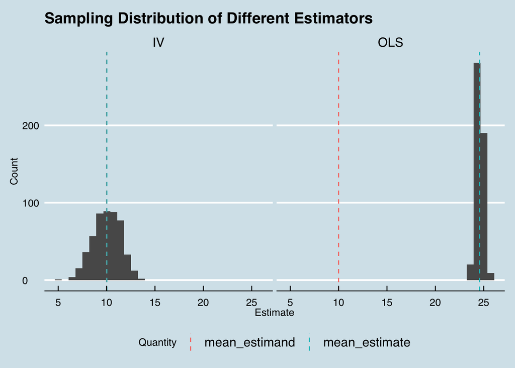

```r
# Step 1: Specify both estimators
iv_design <-
  declare_population(N = 2000,
                     noise = rnorm(N, mean = 10, sd = 4),
                     A = rnorm(N),
                     X = rbinom(N, size = 1, prob = 0.48)) +
  declare_potential_outcomes(D ~ as.numeric(pnorm(Z + A) > 0.5),
                             assignment_variables = "Z") +
  declare_potential_outcomes(Y ~  noise + 10*A + 1.25*X + 10*D,
                             assignment_variables = "D") +
  declare_estimand(ATE = mean(Y_D_1 - Y_D_0)) +
  declare_assignment(blocks = X, block_prob = c(0.6, 0.4),
                     assignment_variable = "Z") +
  declare_estimator(Y ~ D + X | Z + X,
                    model = iv_robust,
                    term = "D",
                    estimand = "ATE",
                    label = "IV")+
  declare_estimator(Y ~ D + X,
                    model = lm_robust,
                    term = "D",
                    estimand = "ATE",
                    label = "OLS")

simulations <- simulate_designs(iv_design, sims = 500)


estimator_performance <- simulations %>%
  group_by(estimator_label) %>%
  summarise(mean_estimand = mean(estimand),
            mean_estimate = mean(estimate))  %>%
  gather(key = "Quantity", value = "Value",
         mean_estimand, mean_estimate)

## Step 2: Creating a figure using ggplot2

library(ggthemes)

figure8 <- ggplot(data = simulations,
                  aes(x = estimate)) +
                  xlab("Estimate") + ylab("Count") +
                  geom_histogram(bins = 30) +
                  facet_wrap(~ estimator_label)+
  geom_vline(
  data = estimator_performance,
  aes(xintercept = Value, color = Quantity),
  size = 0.5,
  linetype = "dashed"
  ) +
  theme_economist() +
  theme(legend.position = "bottom") +
  ggtitle(label = "Sampling Distribution of Different Estimators")

figure8
```

## With Heterogenous Effects

So far we have assumed that $\beta_1$ (effect of $D_i$ on $Y_i$) is constant. That is: $Y_i(1) - Y_i(0) = \beta_1$ $\forall i$. We can relax this assumption but would need monotonicity to identify the complier average causal effect (`LATE`). In this section, I briefly describe each assumption, why we need it, and how we can break it.

First, lets define the estimand:

$$\begin{equation}
CACE = \frac{ITT_Y}{ITT_D} = \frac{E[Y_i | Z_i = 1] - E[Y_i | Z_i = 0]}{E[D_i | Z_i = 1] - E[D_i | Z_i = 0]} = E[Y_i(1) - Y_i(0) | D_i(1) > D_i(0)]
\end{equation}$$

### Independence

> $Z_i$ is as good as randomly assigned. Values of $Z_i$ do not covary with potential outcomes or the type of response to treatment assignment. $\{Y_i(d,z) \forall d,z\}, D_i(Z=1), D_i(Z=0) \perp Z_i$

**Implication**

If the instrument $Z_i$ is not exogenously determined, or conditionally independent, we still have confounding (i.e. open backdoor paths connecting $Z$ and $Y$). Visually, imagine the DAG we had earlier but now there is some unobserved variable $u$ that causes $Y$ and $Z$. In such circumstances, when we estimate the reduced form ($Y_i \sim Z_i$), the backdoor path $Z \leftarrow u \rightarrow Y$ will be unblocked.

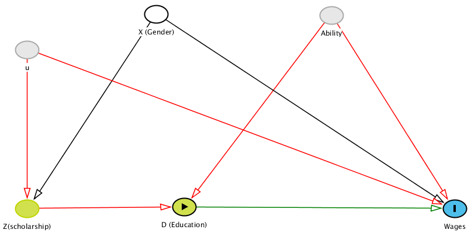

Figure 2: Exogeneity Violation

**DeclareDesign**

We would violate exogeneity by defining the assignment procedure, `declare_assignment(\(\cdot\))`, in terms of `noise` (some unobservable factor that causes $Y$). For example:

`declare_assignment(prob_unit = 0.4 + 0.2*X - 0.25*as.numeric(noise <= 10), simple = TRUE)`

### Excludability

> Potential outcomes respond to treatment status $D_i$, not treatment assignment $Z_i$. The instrument operates through a single known causal channel. Formally: $Y_i(d,0) = Y_i(d,1) = Y_i(d) \forall d$

**Implication:** If the instrument affects outcomes through causal channels other than $D_i$, then the reduced form *overestimates* the effect of $D$ on $Y$. For example, if $Z$ affects $Y$ through $M$ and $D$, $ITT_Y$ combines the effect of both channels.

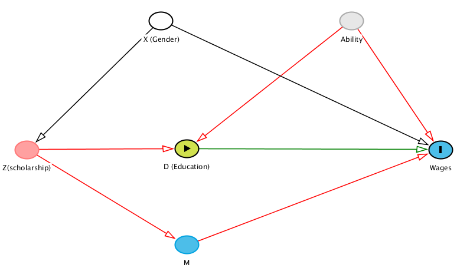

Figure 3: Excludability Violation

**DeclareDesign**

We would violate excludability by defining potential outcomes in terms of `Z` and `D`. Excludability implies that $Y_i(d_i,z_i) = Y_i(d_i)$ (i.e. if we fix $i$’s treatment status $d_i$, then $i$’s outcome will not change because of any changes in their assignment status $z_i$). An excludability violation can take two forms: either $Z_i$ directly affects $Y_i$, or $Z_i$ affects $Y_i$ through a mediator other than $D_i$ ($M_i$ in the DAG above).

What this implies is that potential outcomes are no longer solely a function of $D_i$. Take the case of $Z_i$ directly affecting $Y_i$. We now have four potential outcomes: $Y_i(Z=1,D=1)$, $Y_i(Z=1,D=0)$, $Y_i(Z=0,D=1)$, and $Y_i(Z=0,D=0)$. If we specify a mediator $M_i$, these become: $Y_i(M=1,D=1)$, $Y_i(M=1,D=0)$, $Y_i(M=0,D=1)$, and $Y_i(M=0,D=0)$. Since $M$ is itself a potential outcome with two values - $M_i(Z=1)$ and $M_i(Z=0)$ - we can re-write the four potential outcomes as a function of $D$ and $Z$.

This means we have a slightly complicated estimand.The effect of $D$ on $Y$ is $E[Y|D=1] - E[Y| D =0]$. Think of $E[Y|D=1]$ as being a weighted average of two quantities: $E[Y|Z=1, D=1]$ and $E[Y|Z=0, D=1]$. Similarly, $E[Y|D=0]$ is a weighted average of $E[Y|Z=1, D=0]$, $E[Y|Z=0, D=0]$. So the ATE is essentially the average of $E[Y| D=1, Z=0] - E[Y| D=0, Z=0]$ and $E[Y| D=1, Z=1] - E[Y| D=0, Z=1]$ (i.e. fixing $Z$, and only moving $D$ we calculate the effect for each value of $Z$). In `DeclareDesign` this looks as follows:

**Step 1:** Declare a mediator $M$ that opens an alternative causal pathway from $Z$ to $Y$:

`declare_potential_outcomes(M ~ rnorm(N) + 2*Z, assignment_variables = “Z”)`

**Step 2:** Write $Y$ as a function of $D$ and $M$, remember to specify two assignment variables ($Z$ and $D$):

`declare_potential_outcomes(Y ~ noise + 10*A + 1.25*X + 10*D + 2*(rnorm(N) + 2*Z),assignment_variables = c(D,Z))`

Note: If we specified $M$ instead of $(rnorm(N) + 2\cdot Z)$, $Y$ would have to be a function of $D$ and $M$. Since $M$ is itself a function of $Z$, I specify $Y$ in terms of the *constituents* of $M$, i.e. $(rnorm(N) + 2\cdot Z)$. Now, $Y$ can be a function of $D$ and $Z$, which clearly illustrates the exclusion restriction.

`declare_estimand(CACE = mean(((Y_D_1_Z_0 - Y_D_0_Z_0) + (Y_D_1_Z_1 - Y_D_0_Z_1))/2), subset = D_Z_1 > D_Z_0)`

and

`declare_estimand(ATE = mean(((Y_D_1_Z_0 - Y_D_0_Z_0) + (Y_D_1_Z_1 - Y_D_0_Z_1))/2))`

I reproduce this in code for both the example used in section, and the problem set question. I then produce two tables summarizing the `mean(estimand)` and `mean(estimate)` for each estimator.

```r
# Section Example (Constant Effects)

iv_design <-
  declare_population(
  N = 2000,
  noise = rnorm(N, mean = 10, sd = 4),
  A = rnorm(N),
  X = rbinom(N, size = 1, prob = 0.48)
  ) +
  declare_potential_outcomes(D ~ as.numeric(pnorm(Z + A) > 0.5),
  assignment_variables = "Z") +
  # Z now affects Y through M
  declare_potential_outcomes(M ~ rnorm(N) + 2 * Z,
  assignment_variables = "Z") +
  # The effect of D on Y is 10 for everyone. Compare this to section where D's impact varies by type
  declare_potential_outcomes(Y ~  noise + 10 * A + 1.25 * X + 10 * D + 2 *
  (rnorm(N) + 2 * Z),
  assignment_variables = c(D, Z)) +
  # E[Y | D=1] and E[Y | D=0] is a weighted average of two quantities;
  # I subset to D_Z_1 > D_Z_0 because only compliers satisfy D(Z=1) > D(Z=0)
  declare_estimand(CACE = mean(((Y_D_1_Z_0 - Y_D_0_Z_0) + (Y_D_1_Z_1 - Y_D_0_Z_1)
  ) / 2), subset = D_Z_1 > D_Z_0) +
  declare_estimand(ATE = mean(((Y_D_1_Z_0 - Y_D_0_Z_0) + (Y_D_1_Z_1 - Y_D_0_Z_1)
  ) / 2)) +
  declare_assignment(blocks = X, block_prob = c(0.6, 0.4)) +
  declare_estimator(
  Y ~ D + X | Z + X,
  model = iv_robust,
  term = "D",
  estimand = "CACE",
  label = "IV"
  ) +
  declare_estimator(
  Y ~ D + X,
  model = lm_robust,
  term = "D",
  estimand = "ATE",
  label = "OLS"
  )

simulations <- simulate_designs(iv_design, sims = 500)

estimator_performance <- simulations %>%
  group_by(estimator_label) %>%
  summarise(mean_estimand = mean(estimand),
            mean_estimate = mean(estimate))

estimator_performance %>% knitr::kable(.,
                                        digits = 2,
                                        caption = "Section Example (Exclusion Restriction Violation)")
```

Section Example (Exclusion Restriction Violation)

| estimator_label | mean_estimand | mean_estimate |
| --- | --- | --- |
| IV | 10 | 21.65 |
| OLS | 10 | 26.07 |

```r
# Problem Set Question (Heterogenous effects, Assuming Monotonicity)

pi_CO <- 0.5
pi_AT <- 0.1
pi_NT <- 0.4
pi_DE <- 1 - (pi_CO + pi_AT + pi_NT)

pset_design <-
  declare_population(
  N = 100,
  noise = rnorm(N),
  type = sample(
  c("CO", "AT", "NT", "DE"),
  N,
  replace = TRUE,
  prob = c(pi_CO, pi_AT, pi_NT, pi_DE)
  )
  ) +
  declare_potential_outcomes(D ~ as.numeric(Z == 1 &
  type %in% c("CO", "AT") |
  Z == 0 &
  type %in% c("DE", "AT")),
  assignment_variables = "Z") +
  declare_potential_outcomes(M ~ rnorm(N) + 2 * Z,
  assignment_variables = "Z") +
  declare_potential_outcomes(
  Y ~  noise+-0.5 * D * (type == "CO") +
  0.0 * D * (type == "AT") +
  0.5 * D * (type == "NT") +
  1.0 * D * (type == "DE") +
  2 * (rnorm(N) + 2 * Z),
  assignment_variables = c(D, Z)
  ) +
  declare_estimand(CACE = mean(((Y_D_1_Z_0 - Y_D_0_Z_0) + (Y_D_1_Z_1 - Y_D_0_Z_1)
  ) / 2), subset = type == "CO") +
  declare_estimand(ATE = mean(((Y_D_1_Z_0 - Y_D_0_Z_0) + (Y_D_1_Z_1 - Y_D_0_Z_1)
  ) / 2)) +
  declare_assignment(prob = 0.5, assignment_variable = "Z") +
  declare_estimator(
  Y ~ D | Z,
  model = iv_robust,
  term = "D",
  estimand = "CACE",
  label = "IV"
  ) +
  declare_estimator(
  Y ~ D,
  model = lm_robust,
  term = "D",
  estimand = "ATE",
  label = "OLS"
  )

simulations2 <- simulate_design(pset_design, sims = 500)

estimator_performance2 <- simulations2 %>%
  group_by(estimator_label) %>%
  summarise(mean_estimand = mean(estimand),
  mean_estimate = mean(estimate))


estimator_performance2 %>% knitr::kable(.,
                                        digits = 2,
                                        caption = "Problem Set (Exclusion Restriction Violation)")
```

Problem Set (Exclusion Restriction Violation)

| estimator_label | mean_estimand | mean_estimate |
| --- | --- | --- |
| IV | -0.49 | 7.68 |
| OLS | -0.04 | 1.89 |

### Monotonicity

> The instrument can have no effect on some units but all those affected should be affected in the same way. Formally: $D_i(1) > D_i(0)$

**Implication**

Without monotonicity, $ITT_Y$ is the weighted difference in the treatment effect among compliers and defiers, and $ITT_D \neq \pi_c$. To see this, observe that:

$$\begin{equation}
E[Y | Z = 1] = E[Y_1 | C]\pi_C + E[Y_1 | AT]\pi_{AT} + E[Y_0 | NT]\pi_{NT} + E[Y_0 | D]\pi_D
\end{equation}$$
$$\begin{equation}
E[Y | Z = 0] = E[Y_0 | C]\pi_C + E[Y_1 | AT]\pi_{AT} + E[Y_0 | NT]\pi_{NT} + E[Y_1 | D]\pi_D
\end{equation}$$

So the difference between these quantities, or $ITT_Y$ is:

$$\begin{equation}
E[Y_1 - Y_0 | C]\pi_C - E[Y_1 - Y_0 |D]\pi_D
\end{equation}$$
Similarly,
$$\begin{equation}
E[D | Z = 1] - E[D | Z = 0] = (\pi_C + \pi_{AT}) - (\pi_{AT} + \pi_D) = \pi_C - \pi_D
\end{equation}$$

**Note:**

When compliers respond differently to treatment than defiers, the ratio estimator $\frac{ITT_Y}{ITT_D}$ becomes:

$$\begin{equation}
\frac{ITT_Y}{ITT_D} = \frac{E[Y_1 - Y_0 | C]\pi_C - E[Y_1 - Y_0 |D]\pi_D}{(\pi_C - \pi_D)}
\end{equation}$$

Now imagine constant effects, i.e. $E[Y_1 - Y_0 | C] = E[Y_1 - Y_0 |D] = \beta_1$. Then we can rewrite the above as:

$$\begin{equation}
\frac{ITT_Y}{ITT_D} = \frac{\beta_1(\pi_C - \pi_D)}{(\pi_C - \pi_D)} = \beta_1
\end{equation}$$

This is why monotonicity was not assumed when I derived the $\beta_{2SLS}$ under constant effects.

### Non-Zero First Stage

> The instrument must produce some variation in D. Formally: $E[D_i | Z_i =1] - E[D_i | Z_i =0] \neq 0$.

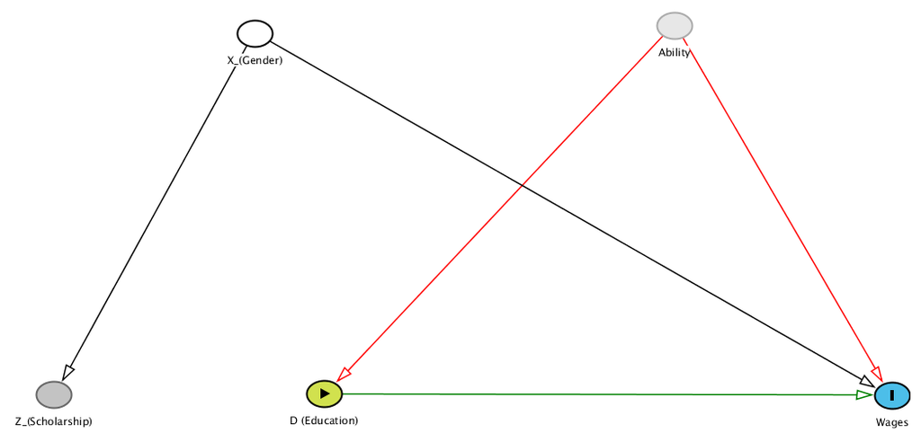

Figure 4: Weak First Stage

This is necessary because the Wald estimator is undefined if $E[D_i | Z_i =1] - E[D_i | Z_i =0] = 0$. Note also that as $E[D_i | Z_i =1] - E[D_i | Z_i =0] \rightarrow 0$, we amplify any biases in the $ITT_Y$ due to exclusion restriction violations. The intuition behind this is that when we have exclusion restriction violations, the $ITT_Y$ *overestimates* the effect of $D$ on $Y$. If we then rescale this estimate by a very small $\pi_C$, we “blow-up” the bias in the reduced form estimate.

**DeclareDesign**

To model this in Declare Design, we must do two things: (1) $Z$ should not determine values of $D$ beacuse if $Z \perp D$, we will get a close-to-zero first stage; (2) $D$ must still be *endogenous* (i.e. caused by a predictor of $Y$).

Here is code using both the section example, and problem set question, illustrating this.

```r
# Section Example

iv_design <-
  declare_population(
  N = 2000,
  noise = rnorm(N, mean = 10, sd = 4),
  A = rnorm(N),
  X = rbinom(N, size = 1, prob = 0.48),
  # Specify Z in the population because it is just a background variable
  Z = X*rbinom(N, size = 1, prob = 0.6) + (1-X)*rbinom(N, size = 1, prob = 0.4)
  ) +
  declare_potential_outcomes(Y ~  noise + 10 * A + 1.25 * X + 10 * D,
  assignment_variables = "D") +
  declare_estimand(ATE = mean(Y_D_1 - Y_D_0)) +
  # D must be endogenous (noise causes D and Y)
  # D must not be caused by Z
  declare_assignment(prob_unit = pnorm(noise), simple = TRUE,
  assignment_variable = "D"
  ) +
  declare_estimator(
  Y ~ D | Z,
  model = iv_robust,
  term = "D",
  estimand = "ATE",
  label = "IV"
  ) +
  declare_estimator(
  Y ~ D,
  model = lm_robust,
  term = "D",
  estimand = "ATE",
  label = "OLS"
  )
simulations <- simulate_designs(iv_design, sims = 500)

estimator_performance <- simulations %>%
  group_by(estimator_label) %>%
  summarise(mean_estimand = mean(estimand),
            mean_estimate = mean(estimate))

estimator_performance %>% knitr::kable(.,
                                        digits = 2,
                                        caption = "Section Example (Weak First Stage)")
```

Section Example (Weak First Stage)

| estimator_label | mean_estimand | mean_estimate |
| --- | --- | --- |
| IV | 10 | -1.398186e+11 |
| OLS | 10 | 2.069000e+01 |

```r
# Problem Set Question

pi_CO <- 0.5
pi_AT <- 0.1
pi_NT <- 0.4
pi_DE <- 1 - (pi_CO + pi_AT + pi_NT)

pset_design <-
  declare_population(N = 100,
                     noise = rnorm(N),
                     type = sample(c("CO", "AT", "NT", "DE"),
                                   N,
                                   replace = TRUE,
                                   prob = c(pi_CO, pi_AT, pi_NT, pi_DE)),
                      # Specify Z in the population because it is just a background variable
                     Z = rbinom(N, size = 1, prob = 0.5)) +
  declare_potential_outcomes(Y ~  noise +
                               -0.5 * D * (type == "CO") +
                               0.0 * D * (type == "AT") +
                               0.5 * D * (type == "NT") +
                               1.0 * D * (type == "DE"),
                             assignment_variables = "D") +
  declare_estimand(CACE = mean(Y_D_1 - Y_D_0), subset = type == "CO") +
  declare_estimand(ATE = mean(Y_D_1 - Y_D_0)) +
  # Specify D as a function of noise because it is endogenous
  # D should not be a function of Z (this ensures a weak first stage)
  declare_assignment(prob_unit = pnorm(noise), simple = TRUE,
                     assignment_variable = "D") +
  declare_estimator(Y ~ D | Z,
                    model = iv_robust,
                    term = "D",
                    estimand = "CACE",
                    label = "IV") +
  declare_estimator(Y ~ D,
                    model = lm_robust,
                    term = "D",
                    estimand = "ATE",
                    label = "OLS")

simulations2 <- simulate_design(pset_design, sims = 500)
# Note: you may end up with some IV estimates being NA
# This happens because when the first stage is very close to 0
# ITT / 0 = Inf.
# To factor this in, include na.rm = TRUE below

estimator_performance2 <- simulations2 %>%
  group_by(estimator_label) %>%
  summarise(mean_estimand = mean(estimand, na.rm = T),
  mean_estimate = mean(estimate, na.rm = T))


estimator_performance2 %>% knitr::kable(.,
                                        digits = 2,
                                        caption = "Problem Set (Weak First Stage)")
```

Problem Set (Weak First Stage)

| estimator_label | mean_estimand | mean_estimate |
| --- | --- | --- |
| IV | -0.50 | -1.617827e+11 |
| OLS | -0.05 | 1.080000e+00 |